# multipanel_code_along.Rmd

Peter Higgins

5/14/2020

## Preparing to Code-Along for Multipanel Plots

- make sure you have {tidyverse}, {patchwork}, and {ggtext} packages installed
- library() all 3 packages
- Details at the {patchwork} packagedown site:

https://patchwork.data-imaginist.com

- Take 60 seconds to install, library, and explore

## What Patchwork Can Do For You

- Start with Single (related) Plots
- Use a simple user interface to combine them
- Arrange at will in rows and columns
- Nesting included

## Preparing data for 4 dummy plots

```r
# Library calls
library(tidyverse)
library(ggtext)
library(patchwork)

# make dummy figures
d1 <- runif(500)
d2 <- rep(c("Treatment", "Control"), each=250)
d3 <- rbeta(500, shape1=100, shape2=3)
d4 <- d3 + rnorm(500, mean=0, sd=0.1)
plotData <- data.frame(d1, d2, d3, d4)
```

## Single Plots, Plot 1 through Plot 4

```r
p1 <- ggplot(data=plotData) +
  geom_point(aes(x=d3, y=d4)) + labs(tag = "A") +
  theme(plot.background =
          element_rect(color='black'))
p1

p2 <- ggplot(data=plotData) + geom_boxplot(aes(x=d2, y=d1, fill=d2))+
  theme(legend.position="none") + labs(tag = "B") +
  theme(plot.background = element_rect(color='black'))
p2

p3 <- ggplot(data=plotData) +
  geom_histogram(aes(x=d1, color=I("black"), fill=I("orchid"))) + labs(tag = "C") +
  theme(plot.background = element_rect(color='black'))
p3

p4 <- ggplot(data=plotData) +
  geom_histogram(aes(x=d3, color=I("black"), fill=I("goldenrod"))) + labs(tag = "D") +
  theme(plot.background = element_rect(color='black'))
p4
```

[output not shown]

## Now Combine These Plots into a Multipanel Plot with {patchwork}

### Use | to Combine Plots in a row!

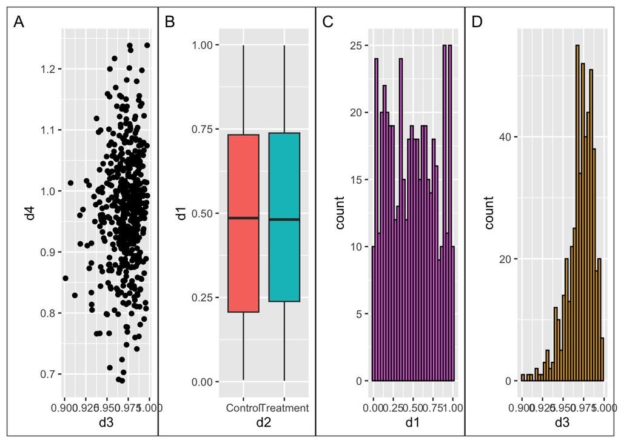

```r
p1 <- ggplot(data=plotData) +
  geom_point(aes(x=d3, y=d4)) + labs(tag = "A") +
  theme(plot.background =
          element_rect(color='black'))

p2 <- ggplot(data=plotData) + geom_boxplot(aes(x=d2, y=d1, fill=d2))+
  theme(legend.position="none") + labs(tag = "B") +
  theme(plot.background = element_rect(color='black'))

p3 <- ggplot(data=plotData) +
  geom_histogram(aes(x=d1, color=I("black"), fill=I("orchid"))) + labs(tag = "C") +
  theme(plot.background = element_rect(color='black'))

p4 <- ggplot(data=plotData) +
  geom_histogram(aes(x=d3, color=I("black"), fill=I("goldenrod"))) + labs(tag = "D") +
  theme(plot.background = element_rect(color='black'))


p1 | p2 | p3 | p4
```

### Use / to Combine Plots in a Column!

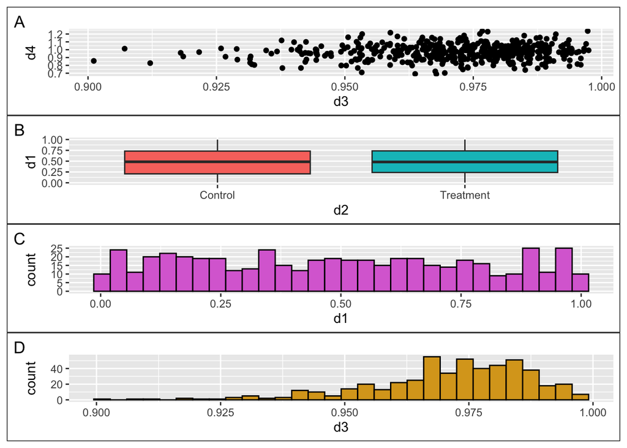

```r
p1 <- ggplot(data=plotData) +
  geom_point(aes(x=d3, y=d4)) + labs(tag = "A") +
  theme(plot.background =
          element_rect(color='black'))

p2 <- ggplot(data=plotData) + geom_boxplot(aes(x=d2, y=d1, fill=d2))+
  theme(legend.position="none") + labs(tag = "B") +
  theme(plot.background = element_rect(color='black'))

p3 <- ggplot(data=plotData) +
  geom_histogram(aes(x=d1, color=I("black"), fill=I("orchid"))) + labs(tag = "C") +
  theme(plot.background = element_rect(color='black'))

p4 <- ggplot(data=plotData) +
  geom_histogram(aes(x=d3, color=I("black"), fill=I("goldenrod"))) + labs(tag = "D") +
  theme(plot.background = element_rect(color='black'))


p1 / p2 / p3 / p4
```

### Use + to Combine Plots in a 2 x 2 Grid!

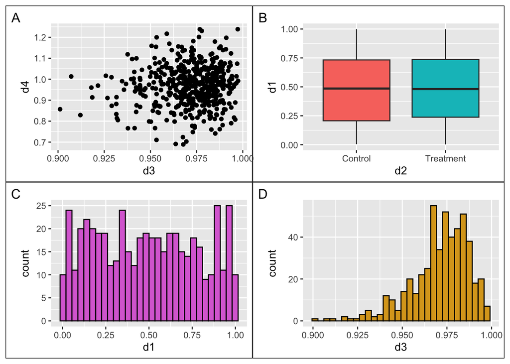

```r
p1 + p2 + p3 + p4
```

## Make More Complex Multipanel Plots with Nesting!

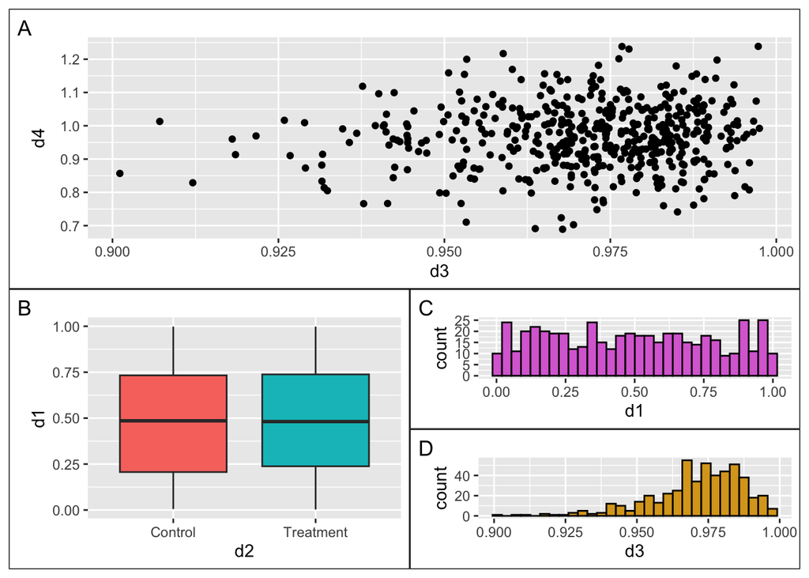

```r
p1 / (p2 | (p3/p4))
```

## Code-Along Break for Patchwork

- Look up the patchwork packagedown website, at
- https://patchwork.data-imaginist.com/
- Review the guides
- Try it out with plots p1 - p4
- Be creative with (), / , |, and plot_layout()
- Take 3 minutes to arrange some plots in the code chunk below

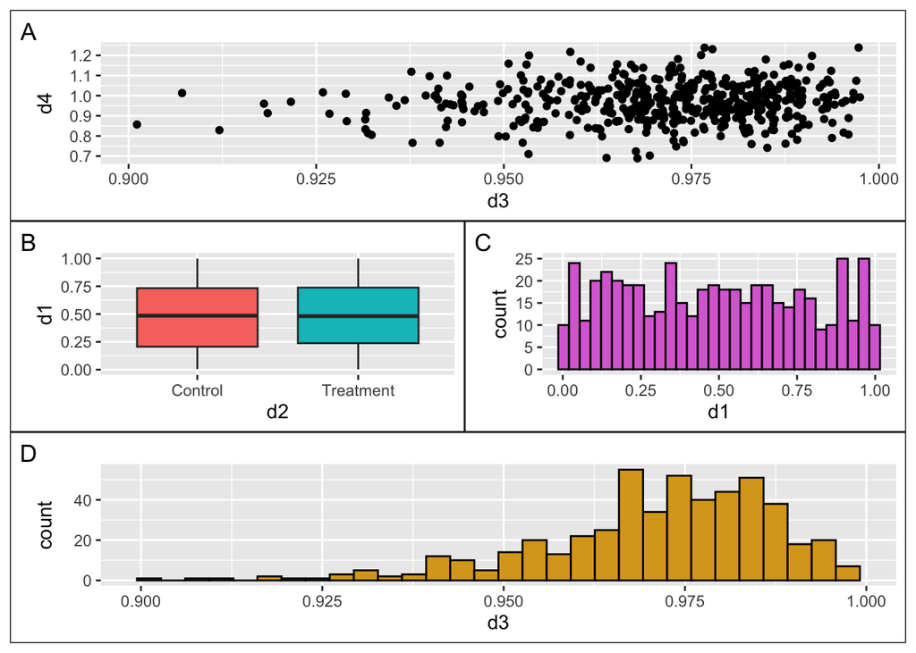

```r
p1 / ( p2 | p3 ) / p4
```

## This is Great, but How to Add a Combined Legend?

## The Side-Quest into {ggtext}: This Turns Out to Be Part of the Solution!

## The {ggtext} package

- Packagedown site at https://wilkelab.org/ggtext/
- allows HTML tag formatting or markdown formatting of text within ggplots!
- color, italics, bold, images, boxes, superscripts
- Can be used in axis labels, legend text, annotations, tick labels
- uses element_markdown() or element_textbox() in place of element_text()
- multi-line labels with `<br>`
- can use inline CSS properties including color, font-size, and font-family

## Fun with {ggtext}: Replace Legends with Colored Text

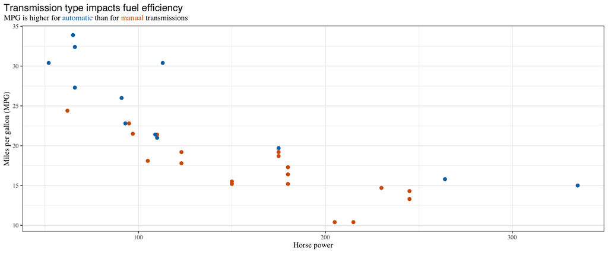

## Fun with {ggtext}: Add boxes to axes, titles

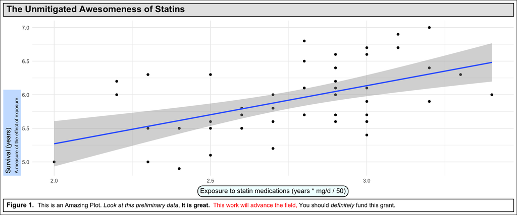

## Returning to The Quest to Add a Combined Legend

### Failed Attempts

- With a TextGrob - bad
- with a {ggtext} caption - not great
- with a {ggtext} textbox_grob - closer
  - Odd spacing
  - Turns out each row set to equal height
- with a {ggtext} plot_annotation - very close!

## Code and Image - {ggtext} plot_annotation

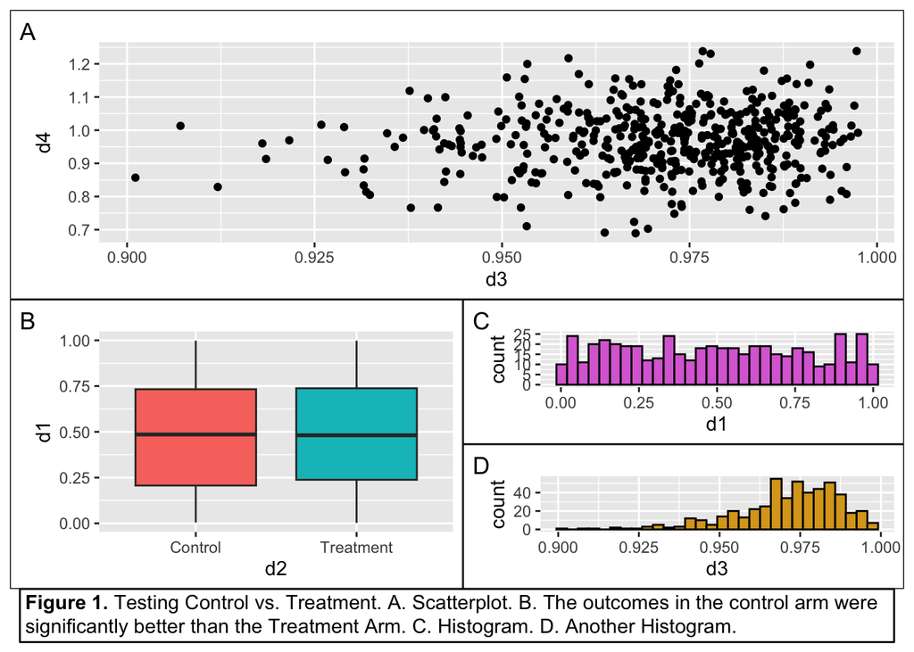

```r
fig_legend <- plot_annotation(
  caption = "**Figure 1.**  Testing Control vs. Treatment.   A. Scatterplot.
  B. The outcomes in the control arm were significantly better than
  the Treatment Arm. C. Histogram. D. Another Histogram.",
  theme = theme(
    plot.caption = element_textbox_simple(
      size = 11,
      box.colour = "black",
      linetype = 1,
      padding = unit(c(3, 3, 3, 3), "pt"),
      r = unit(0, "pt")  )  ) )
p1 + {
  p2 + {
    p3 +
      p4 +
      plot_layout(ncol=1)
  }
} + fig_legend +
  plot_layout(ncol=1)
```

## Now Add the Legend - with a {ggtext} plot_annotation

- Very close, but funky margins (narrower plot_annotation)
- turns out that this inherits margins from plot margins above - now applied to the caption
- can assign negative left and right margins (5.5 pt) to counteract the default plot margins.

## Now Add the Legend - Attempt 5 - Solution!

- With negative left and right margins (5.5 pt)

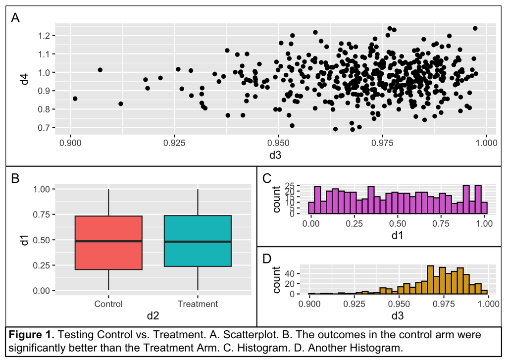

```r
fig_legend <- plot_annotation(
  caption = "**Figure 1.**  Testing Control vs. Treatment.   A. Scatterplot.
  B. The outcomes in the control arm were significantly better than
  the Treatment Arm. C. Histogram. D. Another Histogram.",
  theme = theme(
    plot.caption = element_textbox_simple(
      size = 11,
      box.colour = "black",
      linetype = 1,
      padding = unit(c(3, 3, 3, 3), "pt"),
      margin = unit(c(0, -5.5, 0, -5.5), "pt"),
      r = unit(0, "pt")  ) ) )

p1 + {
  p2 + {
    p3 + p4 + plot_layout(ncol=1)}} +
  fig_legend +
  plot_layout(ncol=1)
```

## Lessons Learned

- The #rstats community is awesome
- Use {reprex} to ask questions on RStudio Community and Stack Overflow
- Lots of people are willing to help if you can come up with a *minimal* reproducible example and  
  can state your question (and your end goal) clearly

# Links to RStudio Community and StackOverflow Discussions

[RStudio Community](https://community.rstudio.com/t/plot-in-a-box-with-long-text-legend-in-a-box/51962)  
https://community.rstudio.com/t/plot-in-a-box-with-long-text-legend-in-a-box/51962

[Stack Overflow](https://stackoverflow.com/questions/60142452/multipanel-plots-with-spanning-figure-legend-in-r-with-ggtext-and-gridtext-in-r)  
https://stackoverflow.com/questions/60142452/multipanel-plots-with-spanning-figure-legend-in-r-with-ggtext-and-gridtext-in-r

## Other Cool Stuff I Used that Is Worth Checking Out

First time using {xaringan} for a presentation  
https://github.com/yihui/xaringan

The {xaringanthemer} package for the maize and blue color scheme and fonts  
https://pkg.garrickadenbuie.com/xaringanthemer/

The {countdown} package for the timer  
https://github.com/gadenbuie/countdown

Side-by-Side Code and Plots in {xaringan}  
https://www.garrickadenbuie.com/blog/decouple-code-and-output-in-xaringan-slides/

Code Highlighting in {xaringan}  
https://www.garrickadenbuie.com/blog/highlight-lines-without-breaking-the-code-in-xaringan/

{reprex} for minimal reproducible examples to ask questions  
https://reprex.tidyverse.org/